# (Don't be) Bullied into Bad Science

```
Stephen J Eglen                  Cambridge Computational Biology Institute
https://sje30.github.io          University of Cambridge
sje30@cam.ac.uk                  @StephenEglen
```

Slides: <http://bit.ly/eglen-riot> (CC-BY license)

#### Declarations

1. Member of *Bullied into Bad Science* campaign
2. Affiliate editor of *bioRxiv*
3. Senior editor of *Scientific Data*

## Acknowledgements

1. Corina Logan and Laurent Gatto.
2. Joined by Ross Mounce, Adrian Curry and myself.  Joined by Lauren Maggio.

http://bulliedintobadscience.org has most of the key background

Do ask questions!

Thanks to Ben Farrar and Yvonne Nobis for material.

## What does it mean to be bullied into bad science?

1. Science is a competitive arena; long work hours culture
2. Race to publish first
3. Not being allowed to shared resources
4. . . .

# Problems

## We are evaluated on where, not what, we publish

Evaluation of research by impact factor or journal title

`$$I_y = \frac{C_{y-1} + C_{y-2}}{P_{y-1} + P_{y-2}}$$`

`\(C_y\)` = number of citations in year y, `\(P_y\)` = number of publications
in year y...

How could this possibly go wrong?

Strong pressure e.g. in China to pressure in journals with impact
factor over some threshold (5).

So many ways to game the system: *A user's guide to inflated and
manipulated impact factors* [(Ioannidis and Thombs, 2019)](https://www.ncbi.nlm.nih.gov/pubmed/31206647).

## Current status of Open Access

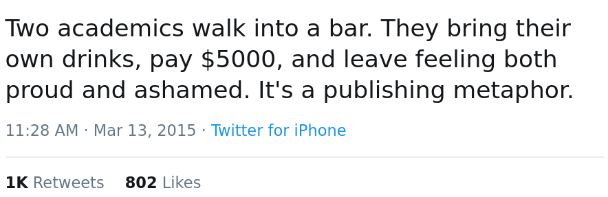

[@AcademicsSays 2015](https://twitter.com/academicssay/status/576343972483842048)

## Reproducibility crisis

Crisis?  What crisis?  Science is getting better, right?

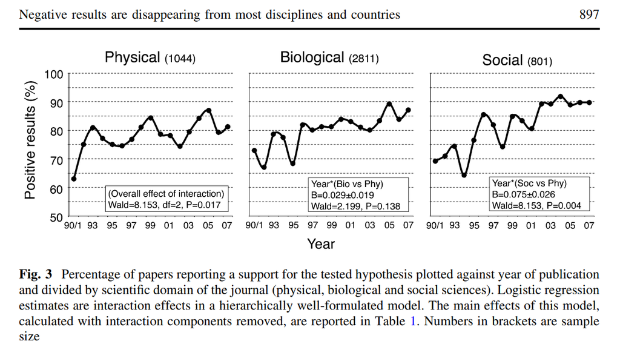

## So what if we are wrong?

"Most models are wrong, but some are useful".  (George Box)

"Most papers are wrong, but some are useful".  (Me).

## Research life cycle being commercialised

See seminar given *this afternoon* in [Zurich](https://productmanagementfestival.com/conference/turning-data-into-revenue-monetizing-data-assets/?sf223451063=1)

[figure not shown]

Longo DL, Drazen JM (2016) Data Sharing. N Engl J Med 374:276–277
<http://dx.doi.org/10.1056/NEJMe1516564>.

Data sharing sounds great ... but

1. Someone not involved in collecting data may misunderstand it.

2. "a new class of research person will emerge --- people who had
nothing to do with the design and execution of the study but use
another group’s data for their own ends, possibly stealing from the
research productivity planned by the data gatherers, or even use the
data to try to disprove what the original investigators had posited.
There is concern among some front-line researchers that the system
will be taken over by what some researchers have characterized as
**``research parasites''**."

Response from the community was to embrace the term "resesarch
parasite", e.g. <https://twitter.com/dataparasite>

This is just good science.  I think there are few valid reasons for
not sharing data.

## Data sharing

Often seen as giving away competitive advantage.

Funders allow data citations and can often lead to new collaborations
/ data papers.

# Solutions?

## What can you as a researcher do?

- Forget about the journal title and its impact factor, share with your
colleagues interesting research that you find (Twitter).

- Evaluating research: use the Sydney Brenner "trick"
[(Brenner, 1995)](http://dx.doi.org/10.1016/S0960-9822%2895%2900109-X)

"we should remind ourselves that what matters absolutely is the scientific
     content of a paper and that nothing will substitute for either knowing it
	or reading it"

- Find a mutual network (reproducibility crowd)

- Investigate preprints . . .

## Preprints

[figure not shown]

## Why preprint?

Advantages (https://www.plos.org/why-preprint):

1. Rapid dissemination of results
2. Establish priority
3. Increased attention/citations
4. Career advancement
5. Community
6. Unlimited / timely updates

Also: potential for early feedback, error reduction, improved
citations, editors might fish for papers.

## When to submit a preprint?

Estimates from
https://nikokriegeskorte.org/2016/03/13/the-selfish-scientists-guide-to-preprint-posting/

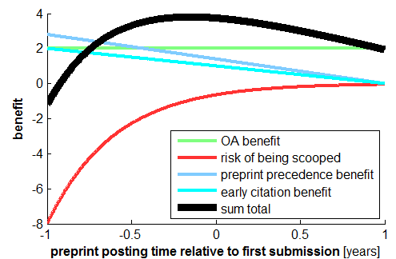

Selfish approach, adopted by many: submit preprint at time
of submissions.

## Moral or selfish approach to sharing?

[figure not shown]

10.1186/s13059-015-0850-7

## Selfish reasons to share

Why not align what is good for science with what is good for
scientists?

1. Funding mandates (REF + enforcement from Wellcome Trust)
2. Credit through data papers
3. Fixes data bugs / errors in analysis
4. Prevent data loss [(Vines et al 2014)](http://www.ncbi.nlm.nih.gov/pubmed/24361065). e.g. students have a habit of leaving...
5. Your future self is probably one of the main beneficiaries of
   sharing.
6. *Now* is a very good time to be an open scientist.
7. Leads to further collaborations
8. Reviewers can do more work...

## Rule 1: Data should be shared

Given the cost of generating data, I think data relating to a
publication should be shared along with the paper.

Funders (and increasingly many, but not all, journals) agree.

## Pregistration studies

## Evaluate journal subscription model

Think about which journals you support, by sending papers and
reviewing.

Support OA journals as authors and reviewers.  (Ever asked a journal
for permission to republish one of your own figures?)

Check out status of journal via Sherpa/Romeo service.

## What can your institutions & funders do?

- sign up to DORA (Declaration of Research Assessment)
(Wellcome Trust have solved this problem).  Signing is easy, enforcing
is hard.

- Give ECR a voice within institutions.

- Recognise all research artefacts, not just papers, as valuable
  outputs.

- Give academics more ownership of funds.  "Do you really want to
   spend 5K on an APC, versus other uses in your lab?"

- Routes to OA need to be generate less admin for librarians /
   funders, not more.  Green OA achieves that.

- Support diamond OA initiatives led by academics and academic
   societies.

## Conclusions

- Many reasons to feel bad...

- But there are lots of reasons for optimism at new ways of doing
  science.

- Learn how to become an open scientist and use modern tools.

- Science improves one preprint submission at a time.

- Read more at http://bulliedintobadscience.org and sign up!